# Power Calculation

Author

Kiera Murray

Published

November 22, 2026

# Part 1: Coding & Statistical Analysis

## 1.1 Setup

```r
# Load packages
pacman::p_load(tidyverse, pwr, presize, pacman, grateful, here, usethis)
```

```r
# Load data
load(here("data", "processed", "acupunc.RData"))
summary(acupunc)
```

```
       id           age            sex              migraine     chronicity
 100    :  1   Min.   :18.00   female:318   migraine    :377   Min.   : 1.00
 101    :  1   1st Qu.:38.00   male  : 59   tension-type:  0   1st Qu.:10.00
 104    :  1   Median :48.00                                   Median :20.00
 105    :  1   Mean   :45.42                                   Mean   :21.86
 108    :  1   3rd Qu.:53.00                                   3rd Qu.:31.00
 112    :  1   Max.   :65.00                                   Max.   :54.00
 (Other):371
 acupuncturist         group          pk1             pk2
 3      :83    acupuncture:194   Min.   : 6.75   Min.   : 0.00
 8      :58    control    :183   1st Qu.:15.00   1st Qu.:10.75
 6      :54                      Median :21.25   Median :16.75
 7      :37                      Mean   :26.61   Mean   :21.42
 9      :34                      3rd Qu.:34.50   3rd Qu.:27.06
 11     :32                      Max.   :94.75   Max.   :98.50
 (Other):79                                      NA's   :69
      pk5              f1              f2              f5               gp
 Min.   : 0.00   Min.   : 3.00   Min.   : 0.00   Min.   : 0.000   18     : 41
 1st Qu.: 8.25   1st Qu.:10.00   1st Qu.: 4.00   1st Qu.: 0.000   12     : 31
 Median :15.00   Median :15.00   Median :10.00   Median : 8.000   41     : 30
 Mean   :18.96   Mean   :16.14   Mean   :10.96   Mean   : 9.265   10     : 23
 3rd Qu.:25.06   3rd Qu.:21.00   3rd Qu.:17.00   3rd Qu.:14.000   16     : 22
 Max.   :87.25   Max.   :28.00   Max.   :28.00   Max.   :28.000   40     : 20
 NA's   :93                                                       (Other):210
```

## 1.2 Recreating the original paper’s power analysis

The original paper’s protocol states:

*A sample size calculation was undertaken using values adapted from Vincent’s (1989) trial . . . We assumed that the control group would experience a change in pain score as reported for the placebo group; inflated standard deviations by 25% to reflect the wider inclusion criteria in our trial; a power of 90%; an alpha of 5% and a 25% drop-out rate. We used a minimal, clinically significant difference of 75% calculated as follows: in the Vincent trial, the pain score in the control group reduced by 20%; in our estimation, a reduction of 35% would be the minimum clinically relevant effect of acupuncture treatment, equivalent to a 75% greater decrease in pain in the acupuncture groupr compared to controls.*

*The actual values used in the sample size calculation were: control mean 30; control standard deviation 53; experimental mean 52; experimental standard deviation 64; alpha 0.05; beta 0.1. The result of the calculation is that 288 evaluable subjects are needed or 394 subjects before drop-out, a figure which is appropriately rounded to 400.*

Below, I attempt to replicate the protocol analysis using a t-test approach:

```r
control_mean <- 30
experimental_mean <- 52

control_sd <- 53
experimental_sd <- 64

alpha <- 0.05
power <- 0.90

mean_difference <- experimental_mean - control_mean

pooled_sd <- sqrt(
  (control_sd^2 + experimental_sd^2) / 2
)

effect_size <- mean_difference / pooled_sd
```

pooled standard deviation: 58.76

effect size: 0.374

```r
sample_size <- pwr.t.test(
  d = effect_size,
  sig.level = alpha,
  power = power,
  type = "two.sample",
  alternative = "two.sided"
)

sample_size
```

```
     Two-sample t test power calculation

              n = 150.8713
              d = 0.3744172
      sig.level = 0.05
          power = 0.9
    alternative = two.sided

NOTE: n is number in *each* group
```

151 evaluable patients are needed in each arm, or 302 total. Accounting for a 25% dropout rate,

```r
151 / (1 - 0.25)
```

```
[1] 201.3333
```

202 patients are needed in each arm, or 404 total, before drop-out.

I was unable to reproduce the paper’s results of 288 evaluable subjects or 394 subjects before drop-out.

Even the paper is inconsistent, since 288 accounting for 25% drop-out is not 394:

```r
288 / (1 - 0.25)
```

```
[1] 384
```

## 1.3 ICC analysis for my mixed model

```r
acupunc_acupuncture_only <- acupunc %>%
  filter(group == "acupuncture")
```

```r
# Calculate ICC confidence interval bounds

# Define rho values to analyze
length <- 101 # number of points in the CI vector
rhos <- seq(from=0, to=1, length.out=length) # look at rho values from 0 to 1

# Get CI widths for rho using prec_icc()
# based on my complete migraine data: k = 3, n = 377
conf_widths <- rep(-1, length)
for (i in 1:length){
  conf_widths[i] <- prec_icc(rho = rhos[i], k = 3, n = nrow(acupunc),
                             conf.level = 0.95)$conf.width
}

# Get CI widths for rho using prec_icc()
# based on the acupuncture group only data: k = 3, n = 194
conf_widths_acu <- rep(-1, length)
for (i in 1:length){
  conf_widths_acu[i] <- prec_icc(rho = rhos[i], k = 3,
                                 n = nrow(acupunc_acupuncture_only),
                                 conf.level = 0.95)$conf.width
}

# Calculate CI upper and lower bounds (for complete data only)
lower_bounds <- pmax(0, rhos - conf_widths/2)
upper_bounds <- pmin(1, rhos + conf_widths/2)
```

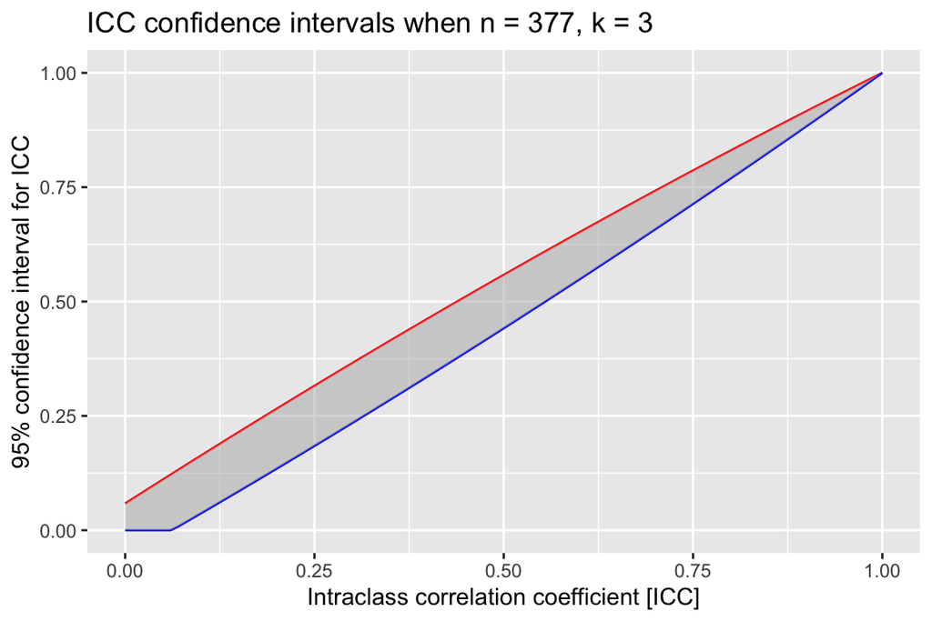

```r
# Make a plot for ICC CI (complete migraine data)
icc_plot <- ggplot(mapping = aes(x = rhos)) +
  geom_line(y = upper_bounds, color = "red") +
  geom_line(y = lower_bounds, color = "blue") +
  geom_ribbon(aes(ymin = lower_bounds, ymax = upper_bounds),
              fill = "grey70", alpha = 0.5) +
  labs(title = "ICC confidence intervals when n = 377, k = 3",
       x = "Intraclass correlation coefficient [ICC]",
       y = "95% confidence interval for ICC")
icc_plot
```

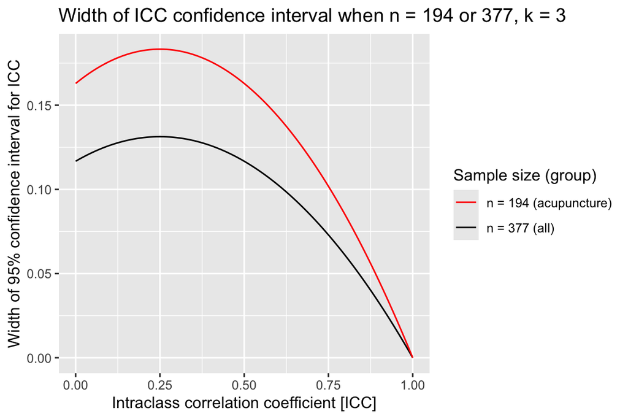

```r
# Make a plot for ICC CI widths (both datasets)

icc_plot2 <- ggplot(mapping = aes(x = rhos)) +
  geom_line(mapping = aes(y = conf_widths, color = "n = 377 (all)")) +
  geom_line(mapping = aes(y = conf_widths_acu, color="n = 194 (acupuncture)")) +
  scale_color_manual(values = c("n = 377 (all)" = "black", "n = 194 (acupuncture)" = "red"),
                     name = "Sample size (group)") +
  labs(title = "Width of ICC confidence interval when n = 194 or 377, k = 3",
       x = "Intraclass correlation coefficient [ICC]",
       y = "Width of 95% confidence interval for ICC")
icc_plot2
```

# Part 2: Draft of Write-up

## 2.1 Sample size calculation

The original protocol’s sample size calculation found that with alpha = 5% and power = 90%, 288 patients would be needed to be evaluated (Vickers 1999). The researchers then assumed a 25% drop-out rate and calculated that they would need to randomize 394 patients, which was then rounded up to 400.

## 2.2 ICC analysis

It is beyond the scope of this research to conduct a simulation-based investigation into power and sample size for a mixed model. However, the mixed model analysis will output an intraclass correlation coefficient (ICC), so confidence intervals for the ICC are explored below.

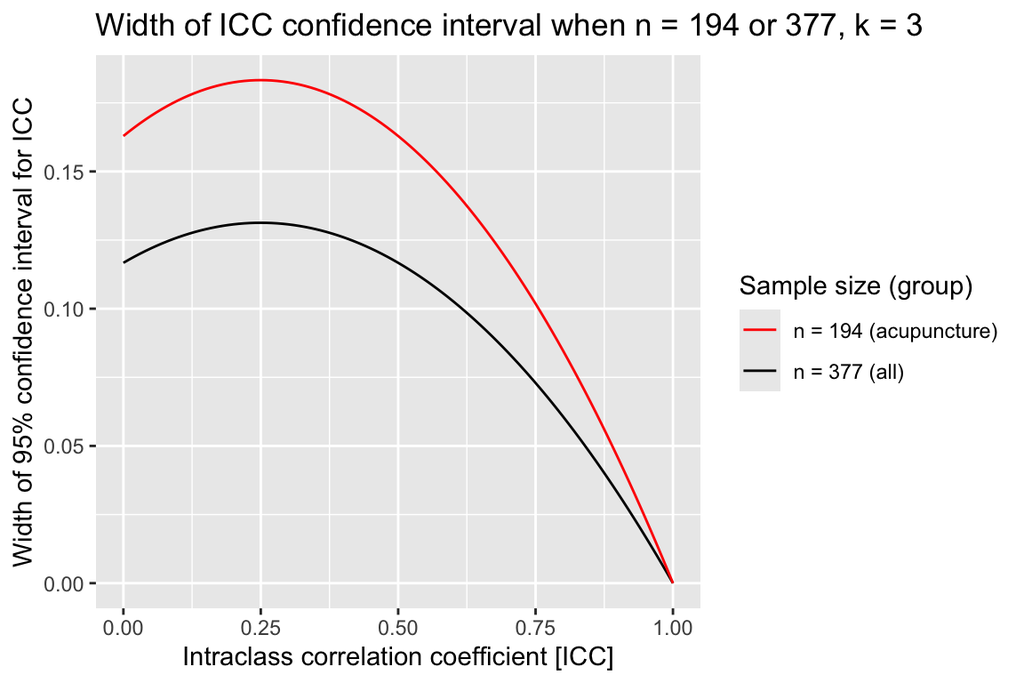

```r
icc_plot2
```